# Start with Python - Practical exercise - Solution

# 1

```python
# do not forget to load necessary packages
import numpy as np
import pandas as pd
# please be aware that the import of pandas and other relevant packages was done here and I do not need to import it again below
```

## 1.1

Write a function that takes two predefined lists:

- list of weights:w
- list of heights: h

and converts it to dataframe. Add appropriate names for each columns of created dataframe.

```python
# predefined lists
w = [20, 30, 40, 50, 60, 70, 80]
h = [120, 130, 140, 150, 160, 170, 180]
```

```python
# one possible solution

def to_df2(w,h):
  df = pd.DataFrame()
  df['w'] = w
  df['h'] = h
  return df

# another way when using arrays
def to_df(w,h):
  a = np.array([w,h])
  a = a.T
  df = pd.DataFrame(data=a, columns=['weight', 'height'])
  return df

w = [20, 30, 40, 50, 60, 70, 80]
h = [120, 130, 140, 150, 160, 170, 180]

print(to_df(w,h))
print(to_df2(w,h))
```

```
   weight  height
0      20     120
1      30     130
2      40     140
3      50     150
4      60     160
5      70     170
6      80     180
    w    h
0  20  120
1  30  130
2  40  140
3  50  150
4  60  160
5  70  170
6  80  180
```

## 1.2

Write a function to convert a NumPy array to a Pandas series.

```python
# with function
def to_series(a):
  return pd.Series(np_array)
np_array = np.array([1, 2, 3, 450])
print(to_series(np_array), '\n')

# without function
np_array = np.array([10, 20, 30, 40, 50])
print("NumPy array:")
print(np_array)
new_series = pd.Series(np_array)
print("Converted Pandas series:")
print(new_series)
```

```
0      1
1      2
2      3
3    450
dtype: int64

NumPy array:
[10 20 30 40 50]
Converted Pandas series:
0    10
1    20
2    30
3    40
4    50
dtype: int64
```

# 2

## 2.1

Write a function to create and display a DataFrame from a specified dictionary data (exam_data)

Resulting dataframe index will be given by a list of labels

exam_data = {} # enter your data acording to labels length

labels = ['a', 'b', 'c', 'd']

```python
labels = ['a', 'b', 'c', 'd']
# fill the data into this dictionary,  enter your data acording to labels length
exam_data  = {
  'name': [ ],
  'score': [ ],
  'attempts': [ ],
  'qualify': [ ]}
# your code
```

```python
# one possible solution with longer label list

def createdf(d,l):
  return pd.DataFrame(d, index=l)

exam_data  = {
    'name': ['Anastasia', 'Dima', 'Katherine', 'James', 'Emily', 'Michael', 'Matthew', 'Laura', 'Kevin', 'Jonas'],
    'score': [12.5, 9, 16.5, np.nan, 9, 20, 14.5, np.nan, 8, 19],
    'attempts': [1, 3, 2, 3, 2, 3, 1, 1, 2, 1],
    'qualify': ['yes', 'no', 'yes', 'no', 'no', 'yes', 'yes', 'no', 'no', 'yes']}
labels = ['a', 'b', 'c', 'd', 'e', 'f', 'g', 'h', 'i', 'j']

data = createdf(exam_data, labels)
data
```

|  | name | score | attempts | qualify |
| --- | --- | --- | --- | --- |
| a | Anastasia | 12.5 | 1 | yes |
| b | Dima | 9.0 | 3 | no |
| c | Katherine | 16.5 | 2 | yes |
| d | James | NaN | 3 | no |
| e | Emily | 9.0 | 2 | no |
| f | Michael | 20.0 | 3 | yes |
| g | Matthew | 14.5 | 1 | yes |
| h | Laura | NaN | 1 | no |
| i | Kevin | 8.0 | 2 | no |
| j | Jonas | 19.0 | 1 | yes |

## 2.2

Write a function to select the specified columns and rows from previously created DataFrame.

Select 'name' and 'score' columns in rows 'b', 'd', 'f', 'g'

```python
# one way is to use iloc and instead of labels use interegrs indexes of wanted rows and columns
print(data.iloc[[1, 3, 5, 6], [0, 1]])

# when we know labels and wan tto use function
def select_rc(df, r,c):
  return(df.loc[r, c])

# it is just a remainder that data comes from previously created dataframe data
rows = ['b', 'd', 'f', 'g']
columns = ['name', 'score']

select_rc(data, rows, columns)
```

```
      name  score
b     Dima    9.0
d    James    NaN
f  Michael   20.0
g  Matthew   14.5
```

|  | name | score |
| --- | --- | --- |
| b | Dima | 9.0 |
| d | James | NaN |
| f | Michael | 20.0 |
| g | Matthew | 14.5 |

## 2.3

Then write a function to select the rows from previously created dataframe, where the score is between 15 and 20 (inclusive).

hint: pandas has between() method

```python
print(data)

def select_score(df, column, limits):
  return df[df[column].between(limits[0], limits[1])] # follows syntax of between() method

select_score(data, 'score', [15, 20])
```

```
        name  score  attempts qualify
a  Anastasia   12.5         1     yes
b       Dima    9.0         3      no
c  Katherine   16.5         2     yes
d      James    NaN         3      no
e      Emily    9.0         2      no
f    Michael   20.0         3     yes
g    Matthew   14.5         1     yes
h      Laura    NaN         1      no
i      Kevin    8.0         2      no
j      Jonas   19.0         1     yes
```

|  | name | score | attempts | qualify |
| --- | --- | --- | --- | --- |
| c | Katherine | 16.5 | 2 | yes |
| f | Michael | 20.0 | 3 | yes |
| j | Jonas | 19.0 | 1 | yes |

# 3

## 3.1

Write a code (function is optional) to append a new row indexed as 'new_row' to previous dataframe and give values to each column that exists in it

Then delete the new row and return the changed and original dataframe.

```python
print(data. columns)

# create dictionary new_row and add it to df using append - ths ignores the original indexes, so you need to reindex
new_row = {
    'name': 'Suresh',
    'score': 18,
    'attempts':1,
    'qualify': 'yes'}
df = data.append(new_row, ignore_index=True)
df.index = labels + ['new_row']
print(df, '\n')

# now drop
df = df.drop('new_row')
print(df, '\n')

# another way when using list and known orded of columns
df.loc['new_row'] = ['Suresh', 18, 1, 'yes']
print(df)
```

```
Index(['name', 'score', 'attempts', 'qualify'], dtype='object')
              name  score  attempts qualify
a        Anastasia   12.5         1     yes
b             Dima    9.0         3      no
c        Katherine   16.5         2     yes
d            James    NaN         3      no
e            Emily    9.0         2      no
f          Michael   20.0         3     yes
g          Matthew   14.5         1     yes
h            Laura    NaN         1      no
i            Kevin    8.0         2      no
j            Jonas   19.0         1     yes
new_row     Suresh   18.0         1     yes

        name  score  attempts qualify
a  Anastasia   12.5         1     yes
b       Dima    9.0         3      no
c  Katherine   16.5         2     yes
d      James    NaN         3      no
e      Emily    9.0         2      no
f    Michael   20.0         3     yes
g    Matthew   14.5         1     yes
h      Laura    NaN         1      no
i      Kevin    8.0         2      no
j      Jonas   19.0         1     yes

              name  score  attempts qualify
a        Anastasia   12.5         1     yes
b             Dima    9.0         3      no
c        Katherine   16.5         2     yes
d            James    NaN         3      no
e            Emily    9.0         2      no
f          Michael   20.0         3     yes
g          Matthew   14.5         1     yes
h            Laura    NaN         1      no
i            Kevin    8.0         2      no
j            Jonas   19.0         1     yes
new_row     Suresh   18.0         1     yes
```

## 3.2

Write a function to insert a new column in existing DataFrame

```python
def new_c(df, col_name, value):
  df[col_name] = value
  return df

df = data.copy() # you can try what will happen when copy is not used here... then you will change data dataframe as well (aliassing)

# assign constant to all rows
df = new_c(df, 'constant', 100)
print(df, '\n')
# assign a value to each row
n_rows = df.shape[0]
df = new_c(df, 'new_value', range(n_rows))
print(data, '\n')
```

```
        name  score  attempts qualify  constant
a  Anastasia   12.5         1     yes       100
b       Dima    9.0         3      no       100
c  Katherine   16.5         2     yes       100
d      James    NaN         3      no       100
e      Emily    9.0         2      no       100
f    Michael   20.0         3     yes       100
g    Matthew   14.5         1     yes       100
h      Laura    NaN         1      no       100
i      Kevin    8.0         2      no       100
j      Jonas   19.0         1     yes       100

        name  score  attempts qualify
a  Anastasia   12.5         1     yes
b       Dima    9.0         3      no
c  Katherine   16.5         2     yes
d      James    NaN         3      no
e      Emily    9.0         2      no
f    Michael   20.0         3     yes
g    Matthew   14.5         1     yes
h      Laura    NaN         1      no
i      Kevin    8.0         2      no
j      Jonas   19.0         1     yes
```

# 4

Write a function to count city wise number of people from a given data set (city, name of the person).

```python
df = pd.DataFrame({
    'name': ['Anastasia', 'Dima', 'Katherine', 'James', 'Emily', 'Michael', 'Matthew', 'Laura', 'Kevin', 'Jonas'],
    'city': ['California', 'Los Angeles', 'California', 'California', 'California', 'Los Angeles', 'Los Angeles', 'Georgia', 'Georgia', 'Los Angeles']
    })
```

```python
# your code

def countnumbers(df, col):
  count  = df.groupby([col]).size() # first create goupby object based on column name and then get size of each group - size returns number of rows
  # now we reset index in count series, this returns dataframe
  df_count = count.reset_index(name='Number of people')
  return df_count

c = countnumbers(df, 'city')
c
```

|  | city | Number of people |
| --- | --- | --- |
| 0 | California | 4 |
| 1 | Georgia | 2 |
| 2 | Los Angeles | 4 |

# 5

## 5.1

Display the default index and set a column as an index in a given dataframe.

```python
df = pd.DataFrame({
    'school_code': ['s001','s002','s003','s001','s002','s004'],
    'class': ['V', 'V', 'VI', 'VI', 'V', 'VI'],
    'name': ['Alberto Franco','Gino Mcneill','Ryan Parkes', 'Eesha Hinton', 'Gino Mcneill', 'David Parkes'],
    'date_Of_Birth': ['15/05/2002','17/05/2002','16/02/1999','25/09/1998','11/05/2002','15/09/1997'],
    'weight': [35, 32, 33, 30, 31, 32],
    'address': ['street1', 'street2', 'street3', 'street1', 'street2', 'street4'],
    't_id':['t1', 't2', 't3', 't4', 't5', 't6']
    })
```

```python
# your code
print(df.index)
df1 = df.set_index('t_id')
print(df1)
```

```
RangeIndex(start=0, stop=6, step=1)
     school_code class            name date_Of_Birth  weight  address
t_id
t1          s001     V  Alberto Franco    15/05/2002      35  street1
t2          s002     V    Gino Mcneill    17/05/2002      32  street2
t3          s003    VI     Ryan Parkes    16/02/1999      33  street3
t4          s001    VI    Eesha Hinton    25/09/1998      30  street1
t5          s002     V    Gino Mcneill    11/05/2002      31  street2
t6          s004    VI    David Parkes    15/09/1997      32  street4
```

## 5.2

Create a multi-index dataframe using two columns and using an index and a selected column.

Then convert index back to column.

```python
# mlti index creating
df1 = df.set_index(['t_id', 'school_code'])
print(df1)

df2 = df.set_index([df.index, 't_id'])
print(df2)

# convert index back to column
df3 = df1.reset_index()
print(df3)

df4 = df2.reset_index().drop(columns=['level_0'])
print(df4)
```

```
                 class            name date_Of_Birth  weight  address
t_id school_code
t1   s001            V  Alberto Franco    15/05/2002      35  street1
t2   s002            V    Gino Mcneill    17/05/2002      32  street2
t3   s003           VI     Ryan Parkes    16/02/1999      33  street3
t4   s001           VI    Eesha Hinton    25/09/1998      30  street1
t5   s002            V    Gino Mcneill    11/05/2002      31  street2
t6   s004           VI    David Parkes    15/09/1997      32  street4
       school_code class            name date_Of_Birth  weight  address
  t_id
0 t1          s001     V  Alberto Franco    15/05/2002      35  street1
1 t2          s002     V    Gino Mcneill    17/05/2002      32  street2
2 t3          s003    VI     Ryan Parkes    16/02/1999      33  street3
3 t4          s001    VI    Eesha Hinton    25/09/1998      30  street1
4 t5          s002     V    Gino Mcneill    11/05/2002      31  street2
5 t6          s004    VI    David Parkes    15/09/1997      32  street4
  t_id school_code class            name date_Of_Birth  weight  address
0   t1        s001     V  Alberto Franco    15/05/2002      35  street1
1   t2        s002     V    Gino Mcneill    17/05/2002      32  street2
2   t3        s003    VI     Ryan Parkes    16/02/1999      33  street3
3   t4        s001    VI    Eesha Hinton    25/09/1998      30  street1
4   t5        s002     V    Gino Mcneill    11/05/2002      31  street2
5   t6        s004    VI    David Parkes    15/09/1997      32  street4
  t_id school_code class            name date_Of_Birth  weight  address
0   t1        s001     V  Alberto Franco    15/05/2002      35  street1
1   t2        s002     V    Gino Mcneill    17/05/2002      32  street2
2   t3        s003    VI     Ryan Parkes    16/02/1999      33  street3
3   t4        s001    VI    Eesha Hinton    25/09/1998      30  street1
4   t5        s002     V    Gino Mcneill    11/05/2002      31  street2
5   t6        s004    VI    David Parkes    15/09/1997      32  street4
```

### 6

Write a function to find the indexes of rows of a specified value of a given column in a dataFrame

```python
def find_ind(df, row_value, col):
  ind = df.index[df[col]==row_value].tolist()
  return ind

find_ind(df, 's001', 'school_code')
```

```
[0, 3]
```

### 7

Create a time series object that has time indexed data. Write a function to select the dates of same year and select the dates between certain dates

hint: methods: DatetimeIndex()

```python
# create time index
index = pd.DatetimeIndex(['2011-09-02',
                          '2012-08-04',
                          '2015-09-03',
                          '2010-08-04',
                          '2015-03-03',
                          '2011-08-04',
                          '2015-04-03',
                          '2012-08-04'
                          ])
# create series with time index
s_dates = pd.Series([0, 1, 2, 3, 4, 5, 6, 7], index=index)
s_dates = s_dates.sort_index() # to avoid warnint on non-monotonic indexing
print("Time series object with indexed data:")
print(s_dates)

print("\nDates of same year:")
print(s_dates['2015'])

print("\nDates between 2012-01-01 and 2012-12-31")
print(s_dates['2012-01-01':'2012-12-31'])
```

```
Time series object with indexed data:
2010-08-04    3
2011-08-04    5
2011-09-02    0
2012-08-04    1
2012-08-04    7
2015-03-03    4
2015-04-03    6
2015-09-03    2
dtype: int64

Dates of same year:
2015-03-03    4
2015-04-03    6
2015-09-03    2
dtype: int64

Dates between 2012-01-01 and 2012-12-31
2012-08-04    1
2012-08-04    7
dtype: int64
```

### 8

Write a function to check whather a day is a business day (weekday) or not.

Hint: Check pandas time series functionality of bdate_range

```python
def is_business_day(date):
    return bool(len(pd.bdate_range(date, date)))
print("Check busines day or not?")
print('2020-12-01: ',is_business_day('2020-12-01'))
```

```
Check busines day or not?
2020-12-01:  True
```

## 9

Write a function to create a period index representing all monthly boundaries of a given year. Also print start and end time for each period object (i.e month) in the said index.

hint: period_range,

- check differences between datetimeindex and periodindex of pandas time series objects
- Each record in a datetimeindex is a pd.Timestamp and represents a single point in time. Each record in a periodindex is a pd.Period and represents a time interval. A period contains a start_time and end_time attribute. They contain a lot of similar methods/attributes, and are often used interchangeably though.

```python
from datetime import datetime, date

def boundaries(start, end):
  dataset = pd.period_range(sdt, edt, freq='M')
  return dataset

sdt = datetime(2022, 1, 1)
edt = datetime(2022, 12, 31)

data = boundaries(sdt, edt)
print("All monthly boundaries of a given year:")
print(data)
print("\nStart and end time for each period object in the said index:")
for d in data:
    print ("{0} {1}".format(d.start_time, d.end_time))
```

```
All monthly boundaries of a given year:
PeriodIndex(['2022-01', '2022-02', '2022-03', '2022-04', '2022-05', '2022-06',
             '2022-07', '2022-08', '2022-09', '2022-10', '2022-11', '2022-12'],
            dtype='period[M]')

Start and end time for each period object in the said index:
2022-01-01 00:00:00 2022-01-31 23:59:59.999999999
2022-02-01 00:00:00 2022-02-28 23:59:59.999999999
2022-03-01 00:00:00 2022-03-31 23:59:59.999999999
2022-04-01 00:00:00 2022-04-30 23:59:59.999999999
2022-05-01 00:00:00 2022-05-31 23:59:59.999999999
2022-06-01 00:00:00 2022-06-30 23:59:59.999999999
2022-07-01 00:00:00 2022-07-31 23:59:59.999999999
2022-08-01 00:00:00 2022-08-31 23:59:59.999999999
2022-09-01 00:00:00 2022-09-30 23:59:59.999999999
2022-10-01 00:00:00 2022-10-31 23:59:59.999999999
2022-11-01 00:00:00 2022-11-30 23:59:59.999999999
2022-12-01 00:00:00 2022-12-31 23:59:59.999999999
```

## 10

Write function to split the given dataframe into groups based on school code. Also check the type of GroupBy object.

```python
student_data = pd.DataFrame({
    'school_code': ['s001','s002','s003','s001','s002','s004'],
    'class': ['V', 'V', 'VI', 'VI', 'V', 'VI'],
    'name': ['Alberto Franco','Gino Mcneill','Ryan Parkes', 'Eesha Hinton', 'Gino Mcneill', 'David Parkes'],
    'date_Of_Birth ': ['15/05/2002','17/05/2002','16/02/1999','25/09/1998','11/05/2002','15/09/1997'],
    'age': [12, 12, 13, 13, 14, 12],
    'height': [173, 192, 186, 167, 151, 159],
    'weight': [35, 32, 33, 30, 31, 32],
    'address': ['street1', 'street2', 'street3', 'street1', 'street2', 'street4']},
    index=['S1', 'S2', 'S3', 'S4', 'S5', 'S6'])
```

```python
print("Original DataFrame:")
print(student_data)

print('\nSplit the said data on school_code wise:')
result = student_data.groupby(['school_code'])

for name,group in result:
    print("\nGroup:")
    print(name)
    print(group)

print("\nType of the object:")
print(type(result))
```

```
Original DataFrame:
   school_code class            name date_Of_Birth   age  height  weight  \
S1        s001     V  Alberto Franco     15/05/2002   12     173      35
S2        s002     V    Gino Mcneill     17/05/2002   12     192      32
S3        s003    VI     Ryan Parkes     16/02/1999   13     186      33
S4        s001    VI    Eesha Hinton     25/09/1998   13     167      30
S5        s002     V    Gino Mcneill     11/05/2002   14     151      31
S6        s004    VI    David Parkes     15/09/1997   12     159      32

    address
S1  street1
S2  street2
S3  street3
S4  street1
S5  street2
S6  street4

Split the said data on school_code wise:

Group:
s001
   school_code class            name date_Of_Birth   age  height  weight  \
S1        s001     V  Alberto Franco     15/05/2002   12     173      35
S4        s001    VI    Eesha Hinton     25/09/1998   13     167      30

    address
S1  street1
S4  street1

Group:
s002
   school_code class          name date_Of_Birth   age  height  weight  \
S2        s002     V  Gino Mcneill     17/05/2002   12     192      32
S5        s002     V  Gino Mcneill     11/05/2002   14     151      31

    address
S2  street2
S5  street2

Group:
s003
   school_code class         name date_Of_Birth   age  height  weight  address
S3        s003    VI  Ryan Parkes     16/02/1999   13     186      33  street3

Group:
s004
   school_code class          name date_Of_Birth   age  height  weight  \
S6        s004    VI  David Parkes     15/09/1997   12     159      32

    address
S6  street4

Type of the object:
<class 'pandas.core.groupby.generic.DataFrameGroupBy'>
```

### Group Work

- Import dataset of your choice and convert it to dataframe, including proper columns naming.
- Explore groupby function of pandas print mean values for seleced groups and plot distribution of data in selected groups
- Depending on the data you selected:
  - apply one-hot/dummy encoding on selected feature
  - apply scaling of selected features
  - select k best features based on Chi2 test

Bonus:

- apply recursive feature selection using
  - from sklearn.feature_selection import RFE
- compare features selected by both methods

```python
# your code
# load packages
from sklearn.datasets import load_iris, load_breast_cancer, load_diabetes, fetch_california_housing
import pandas as pd
import numpy as np

#load dataset
cancer = load_breast_cancer()
# create dataset of a cancer
df= pd.DataFrame(data= np.c_[cancer['data'], cancer['target']],columns= list(cancer['feature_names']) + ['target'])
df
#why np.c_??? - concatenation columnwise
```

|  | mean radius | mean texture | mean perimeter | mean area | mean smoothness | mean compactness | mean concavity | mean concave points | mean symmetry | mean fractal dimension | ... | worst texture | worst perimeter | worst area | worst smoothness | worst compactness | worst concavity | worst concave points | worst symmetry | worst fractal dimension | target |
| --- | --- | --- | --- | --- | --- | --- | --- | --- | --- | --- | --- | --- | --- | --- | --- | --- | --- | --- | --- | --- | --- |
| 0 | 17.99 | 10.38 | 122.80 | 1001.0 | 0.11840 | 0.27760 | 0.30010 | 0.14710 | 0.2419 | 0.07871 | ... | 17.33 | 184.60 | 2019.0 | 0.16220 | 0.66560 | 0.7119 | 0.2654 | 0.4601 | 0.11890 | 0.0 |
| 1 | 20.57 | 17.77 | 132.90 | 1326.0 | 0.08474 | 0.07864 | 0.08690 | 0.07017 | 0.1812 | 0.05667 | ... | 23.41 | 158.80 | 1956.0 | 0.12380 | 0.18660 | 0.2416 | 0.1860 | 0.2750 | 0.08902 | 0.0 |
| 2 | 19.69 | 21.25 | 130.00 | 1203.0 | 0.10960 | 0.15990 | 0.19740 | 0.12790 | 0.2069 | 0.05999 | ... | 25.53 | 152.50 | 1709.0 | 0.14440 | 0.42450 | 0.4504 | 0.2430 | 0.3613 | 0.08758 | 0.0 |
| 3 | 11.42 | 20.38 | 77.58 | 386.1 | 0.14250 | 0.28390 | 0.24140 | 0.10520 | 0.2597 | 0.09744 | ... | 26.50 | 98.87 | 567.7 | 0.20980 | 0.86630 | 0.6869 | 0.2575 | 0.6638 | 0.17300 | 0.0 |
| 4 | 20.29 | 14.34 | 135.10 | 1297.0 | 0.10030 | 0.13280 | 0.19800 | 0.10430 | 0.1809 | 0.05883 | ... | 16.67 | 152.20 | 1575.0 | 0.13740 | 0.20500 | 0.4000 | 0.1625 | 0.2364 | 0.07678 | 0.0 |
| ... | ... | ... | ... | ... | ... | ... | ... | ... | ... | ... | ... | ... | ... | ... | ... | ... | ... | ... | ... | ... | ... |
| 564 | 21.56 | 22.39 | 142.00 | 1479.0 | 0.11100 | 0.11590 | 0.24390 | 0.13890 | 0.1726 | 0.05623 | ... | 26.40 | 166.10 | 2027.0 | 0.14100 | 0.21130 | 0.4107 | 0.2216 | 0.2060 | 0.07115 | 0.0 |
| 565 | 20.13 | 28.25 | 131.20 | 1261.0 | 0.09780 | 0.10340 | 0.14400 | 0.09791 | 0.1752 | 0.05533 | ... | 38.25 | 155.00 | 1731.0 | 0.11660 | 0.19220 | 0.3215 | 0.1628 | 0.2572 | 0.06637 | 0.0 |
| 566 | 16.60 | 28.08 | 108.30 | 858.1 | 0.08455 | 0.10230 | 0.09251 | 0.05302 | 0.1590 | 0.05648 | ... | 34.12 | 126.70 | 1124.0 | 0.11390 | 0.30940 | 0.3403 | 0.1418 | 0.2218 | 0.07820 | 0.0 |
| 567 | 20.60 | 29.33 | 140.10 | 1265.0 | 0.11780 | 0.27700 | 0.35140 | 0.15200 | 0.2397 | 0.07016 | ... | 39.42 | 184.60 | 1821.0 | 0.16500 | 0.86810 | 0.9387 | 0.2650 | 0.4087 | 0.12400 | 0.0 |
| 568 | 7.76 | 24.54 | 47.92 | 181.0 | 0.05263 | 0.04362 | 0.00000 | 0.00000 | 0.1587 | 0.05884 | ... | 30.37 | 59.16 | 268.6 | 0.08996 | 0.06444 | 0.0000 | 0.0000 | 0.2871 | 0.07039 | 1.0 |

569 rows × 31 columns

```
<pandas.core.groupby.generic.DataFrameGroupBy object at 0x7bb62bb189a0>
```

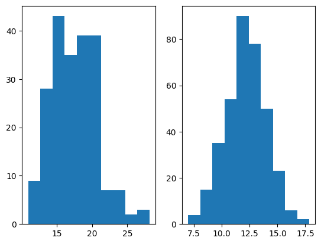

```python
# Explore groupby function of pandas print mean values for seleced groups and plot distribution of data in selected groups
import matplotlib.pyplot as plt
target_groups = df.groupby(by='target')
print(target_groups)

fig,(ax1, ax2) = plt.subplots(1,2)
ax1.hist(target_groups.get_group(0)['mean radius'])
ax2.hist(target_groups.get_group(1)['mean radius'])
```

```python
# Depending on the data you selected:
# apply one-hot/dummy encoding on selected feature
# apply scaling of selected features
# select k best features based on Chi2 test

# I will take another data with categorical features
import io
import requests
# url = "https://raw.githubusercontent.com/cs109/2014_data/master/countries.csv"

url = "https://raw.githubusercontent.com/mwaskom/seaborn-data/master/tips.csv"
s = requests.get(url).content
df = pd.read_csv(io.StringIO(s.decode('utf-8')))
print(df)

# apply one-hot/dummy encoding on selected feature
pd.get_dummies(df['smoker'])

# apply scaling of selected features
from sklearn.preprocessing import StandardScaler, MinMaxScaler, RobustScaler
ss = StandardScaler()
mms = MinMaxScaler()
rs = RobustScaler()
total_bill = pd.DataFrame(df['total_bill'])
total_bill['SS - Population'] = ss.fit_transform(df[['total_bill']])
total_bill['MM - Population'] = mms.fit_transform(df[['total_bill']])
total_bill['RS - Population'] = rs.fit_transform(df[['total_bill']])
total_bill

# select k best features based on Chi2 test - I again use cancer data
X = pd.DataFrame(cancer.data, columns=cancer.feature_names)
y = pd.DataFrame(cancer.target, columns=['target'])
```

```
     total_bill   tip     sex smoker   day    time  size
0         16.99  1.01  Female     No   Sun  Dinner     2
1         10.34  1.66    Male     No   Sun  Dinner     3
2         21.01  3.50    Male     No   Sun  Dinner     3
3         23.68  3.31    Male     No   Sun  Dinner     2
4         24.59  3.61  Female     No   Sun  Dinner     4
..          ...   ...     ...    ...   ...     ...   ...
239       29.03  5.92    Male     No   Sat  Dinner     3
240       27.18  2.00  Female    Yes   Sat  Dinner     2
241       22.67  2.00    Male    Yes   Sat  Dinner     2
242       17.82  1.75    Male     No   Sat  Dinner     2
243       18.78  3.00  Female     No  Thur  Dinner     2

[244 rows x 7 columns]
```

```python
from sklearn.feature_selection import chi2, SelectKBest
skb = SelectKBest(score_func=chi2, k=10)
skb.fit(X, y)

features = skb.feature_names_in_
print(features)
#get only supported features
selected_features = features[skb.get_support()]
print(selected_features)

scores = skb.scores_
print(scores)
selected_scores = scores[skb.get_support()]
print(selected_scores)
```

```
['mean radius' 'mean texture' 'mean perimeter' 'mean area'
 'mean smoothness' 'mean compactness' 'mean concavity'
 'mean concave points' 'mean symmetry' 'mean fractal dimension'
 'radius error' 'texture error' 'perimeter error' 'area error'
 'smoothness error' 'compactness error' 'concavity error'
 'concave points error' 'symmetry error' 'fractal dimension error'
 'worst radius' 'worst texture' 'worst perimeter' 'worst area'
 'worst smoothness' 'worst compactness' 'worst concavity'
 'worst concave points' 'worst symmetry' 'worst fractal dimension']
['mean radius' 'mean texture' 'mean perimeter' 'mean area'
 'perimeter error' 'area error' 'worst radius' 'worst texture'
 'worst perimeter' 'worst area']
[2.66104917e+02 9.38975081e+01 2.01110286e+03 5.39916559e+04
 1.49899264e-01 5.40307549e+00 1.97123536e+01 1.05440354e+01
 2.57379775e-01 7.43065536e-05 3.46752472e+01 9.79353970e-03
 2.50571896e+02 8.75850471e+03 3.26620664e-03 6.13785332e-01
 1.04471761e+00 3.05231563e-01 8.03633831e-05 6.37136566e-03
 4.91689157e+02 1.74449400e+02 3.66503542e+03 1.12598432e+05
 3.97365694e-01 1.93149220e+01 3.95169151e+01 1.34854195e+01
 1.29886140e+00 2.31522407e-01]
[2.66104917e+02 9.38975081e+01 2.01110286e+03 5.39916559e+04
 2.50571896e+02 8.75850471e+03 4.91689157e+02 1.74449400e+02
 3.66503542e+03 1.12598432e+05]
```

```python
#Bonus: https://scikit-learn.org/stable/modules/generated/sklearn.feature_selection.RFE.html
```

## Homework

Write a function to apply log and box-cox transformation. Select a adataset, convert it to pandas dataframe, select feature, display its histogram before transformation, and then after both transformations.

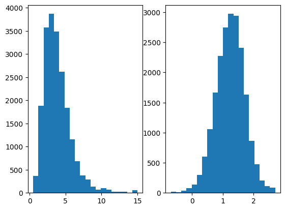

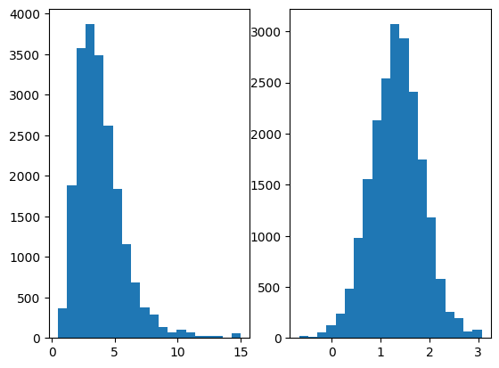

```python
# your code
housing = fetch_california_housing()
df= pd.DataFrame(data= np.c_[housing['data'], housing['target']],columns= list(housing['feature_names']) + ['target'])

# log
X = df['MedInc']
X_log = np.log(X)

fig,(ax1, ax2) = plt.subplots(1,2)
ax1.hist(X,bins=20)
ax2.hist(X_log,bins=20)

# box_cox
from scipy.stats import boxcox
X_bc, best_lambda = boxcox(X)
fig,(ax1, ax2) = plt.subplots(1,2)
ax1.hist(X,bins=20)
ax2.hist(X_bc,bins=20)

# another solution
# https://www.geeksforgeeks.org/box-cox-transformation-using-python/
# or with
# https://scikit-learn.org/stable/modules/generated/sklearn.preprocessing.power_transform.html
```

# Convert jupyter notebook to html

```python
# this is how to mount google drive to be usable and reachable as data storage
from google.colab import drive
drive.mount('/content/drive')
```

```python
# convert colab nb to html
%%shell
jupyter-nbconvert --to html /content/drive/MyDrive/Teaching/MLP/2023_autumn/W1-Solutions.ipynb
```